# Selecase

## Figure 6: Deep-MSA contact map panel / Best clusters contact map panel

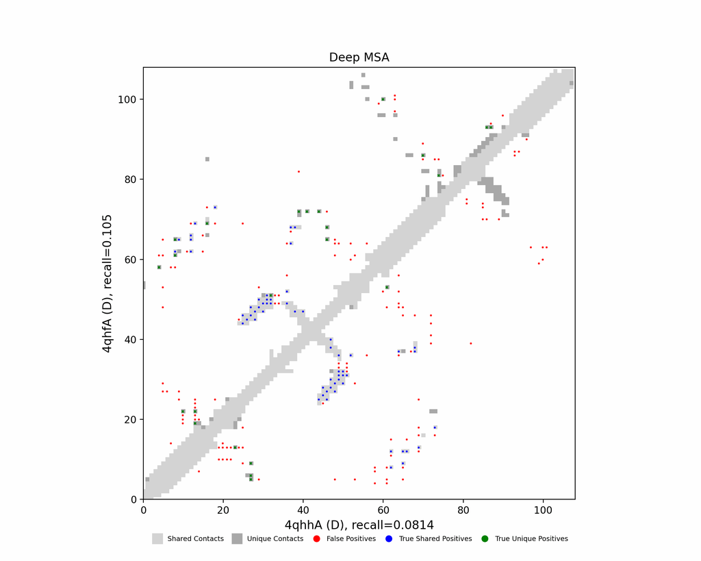

Deep-MSA contact map panel

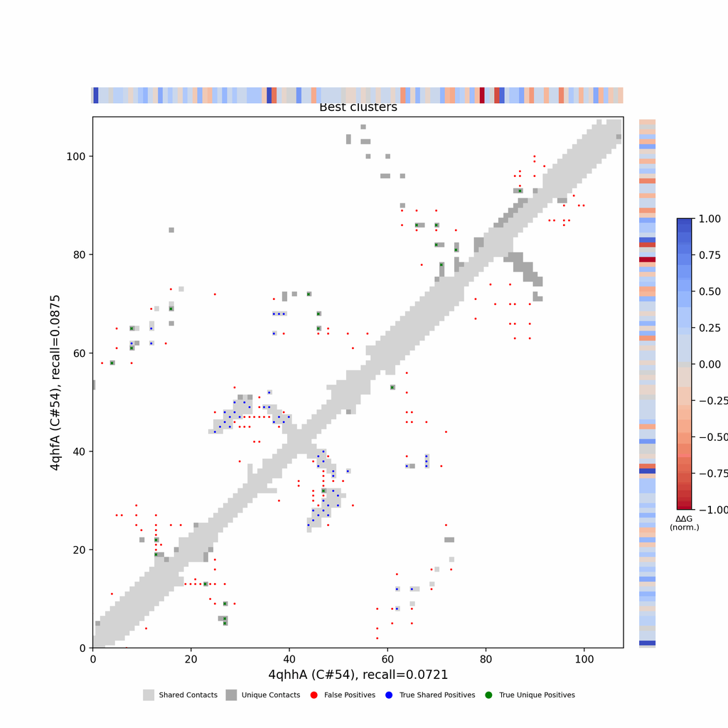

Best clusters contact map panel

## Figure 7: All clusters contact-map mosaic (small multiples).

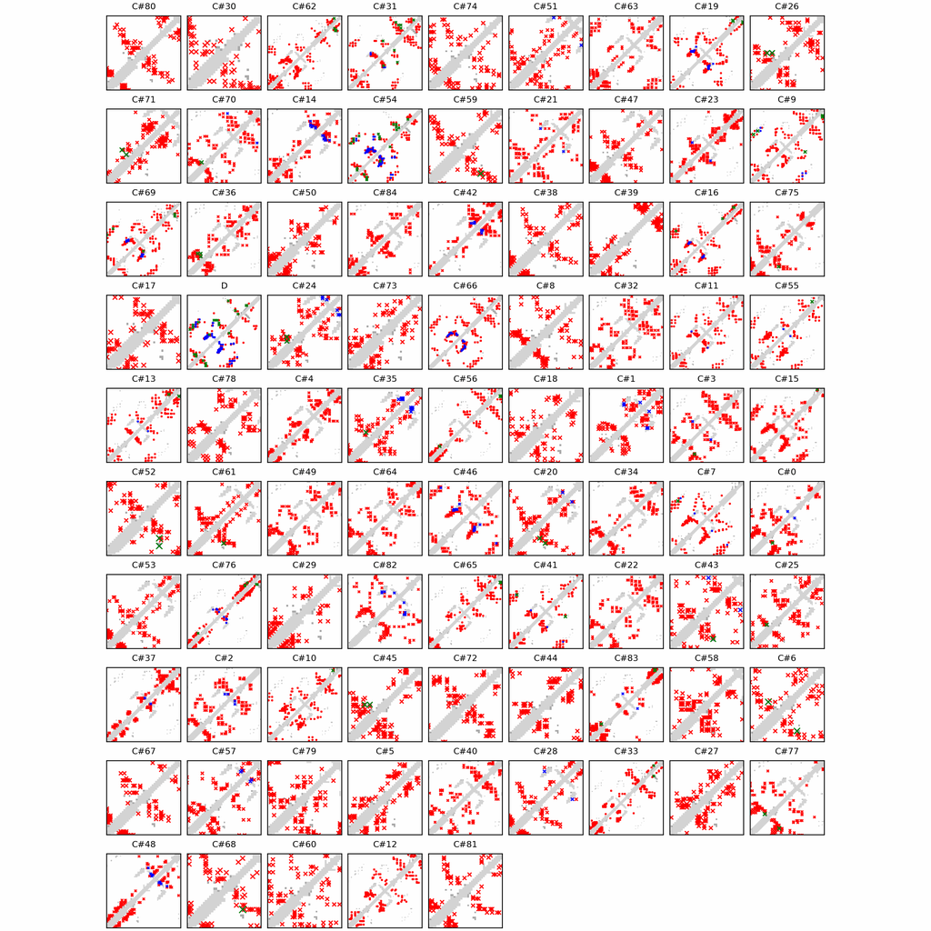

## Figure 8: Phylo null: tree with shuffled cluster fold labels.

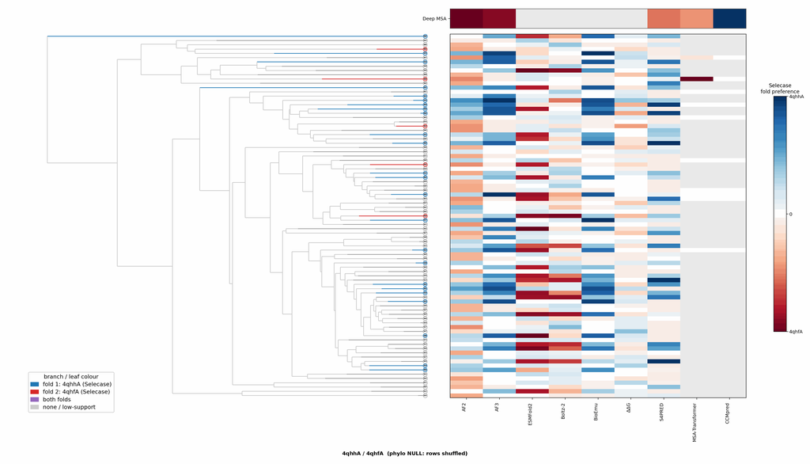

## Cluster metrics table

Per-cluster metrics underlying the figures above.

| cluster | n | neff | AF2_TM1 | AF2_TM2 | AF3_TM1 | AF3_TM2 | RE-MSAT-COM | RE-MSAT1 | RE-MSAT2 | ESM_SEQIDS | ESM_TM1 | ESM_TM2 | ΔΔG_Bias | ΔΔG_Bias_std | ΔΔG_frac_F1 | Boltz2_pref | S4PRED_pref | CCMpred_pref | BioEmu_pref |
| --- | --- | --- | --- | --- | --- | --- | --- | --- | --- | --- | --- | --- | --- | --- | --- | --- | --- | --- | --- |
| Deep | - | - | 0.64 | 0.95 | 0.64 | 0.95 | 0.37 | 0.34 | 0.43 | - | - | - | - | - | - | - | -0.08 | 0.0 | - |
| 000 | 132.0 | 70.0 | 0.65 | 0.94 | 0.64 | 0.94 | 0.02 | 0.02 | 0.02 | 001; 001; 003; 003; 004; 004; 002; 006; 002; 006 | 0.60 ± 0.05 | 0.77 ± 0.11 | 8.35 | 4.66 | 1.0 | 0.0 | -0.06 | 0.0 | -0.18 |
| 001 | 85.0 | 20.0 | 0.65 | 0.79 | 0.64 | 0.92 | 0.04 | 0.03 | 0.03 | 007; 007; 002; 002; 010; 010; 001; 001; 004; 004 | 0.34 ± 0.02 | 0.34 ± 0.02 | 9.43 | 2.91 | 1.0 | 0.0 | -0.08 | 0.0 | -0.18 |
| 002 | 78.0 | 34.0 | 0.29 | 0.32 | 0.28 | 0.28 | 0.02 | 0.02 | 0.02 | 002; 002; 005; 005; 009; 009; 007; 007; 006; 006 | 0.42 ± 0.05 | 0.42 ± 0.04 | 8.15 | 3.49 | 1.0 | -0.05 | -0.08 | 0.0 | -0.03 |
| 003 | 69.0 | 52.0 | 0.65 | 0.93 | 0.64 | 0.94 | 0.02 | 0.02 | 0.01 | 006; 006; 005; 005; 001; 001; 008; 008; 002; 002 | 0.53 ± 0.04 | 0.67 ± 0.04 | 7.68 | 2.56 | 1.0 | -0.05 | 0.04 | 0.0 | -0.18 |
| 004 | 55.0 | 6.0 | 0.3 | 0.28 | 0.48 | 0.5 | 0.0 | 0.0 | 0.0 | 009; 009; 003; 004; 003; 004; 008; 008; 006; 006 | 0.51 ± 0.04 | 0.63 ± 0.04 | 3.73 | 0.87 | 1.0 | -0.01 | 0.07 | 0.0 | -0.01 |
| 005 | 47.0 | 30.0 | 0.32 | 0.35 | 0.64 | 0.93 | 0.0 | 0.0 | 0.0 | 001; 009; 009; 001; 006; 006; 007; 003; 007; 003 | 0.38 ± 0.03 | 0.38 ± 0.04 | 9.61 | 1.56 | 1.0 | 0.02 | -0.08 | 0.0 | -0.18 |
| 006 | 47.0 | 40.0 | 0.66 | 0.92 | 0.64 | 0.94 | 0.0 | 0.0 | 0.0 | 003; 006; 006; 003; 004; 004; 001; 002; 002; 001 | 0.29 ± 0.01 | 0.28 ± 0.01 | 8.12 | 1.4 | 1.0 | 0.0 | -0.08 | 0.0 | -0.19 |
| 007 | 46.0 | 38.0 | 0.65 | 0.92 | 0.68 | 0.7 | 0.02 | 0.02 | 0.01 | 008; 008; 001; 001; 006; 002; 002; 006; 004; 004 | 0.61 ± 0.02 | 0.66 ± 0.12 | 11.57 | 2.54 | 1.0 | -0.0 | -0.07 | 0.0 | -0.18 |
| 008 | 45.0 | 29.0 | 0.64 | 0.7 | 0.64 | 0.93 | 0.0 | 0.0 | 0.0 | 002; 003; 003; 002; 001; 001; 006; 006; 007; 007 | 0.27 ± 0.03 | 0.25 ± 0.04 | 9.3 | 3.05 | 1.0 | -0.01 | -0.08 | 0.0 | -0.18 |
| 009 | 41.0 | 24.0 | 0.23 | 0.29 | 0.29 | 0.25 | 0.03 | 0.08 | 0.05 | 008; 008; 007; 002; 002; 007; 001; 001; 009; 009 | 0.32 ± 0.02 | 0.32 ± 0.01 | 8.04 | 2.9 | 1.0 | -0.06 | -0.06 | 0.0 | -0.01 |
| 010 | 40.0 | 26.0 | 0.21 | 0.25 | 0.34 | 0.41 | 0.0 | 0.0 | 0.02 | - | - | - | 5.5 | 3.05 | 1.0 | -0.07 | 0.0 | - | -0.02 |
| 011 | 37.0 | 22.0 | 0.43 | 0.56 | 0.41 | 0.54 | 0.02 | 0.02 | 0.02 | - | - | - | 7.18 | 1.8 | 1.0 | -0.12 | 0.03 | - | -0.07 |
| 012 | 36.0 | 24.0 | 0.32 | 0.46 | 0.37 | 0.51 | 0.0 | 0.0 | 0.0 | - | - | - | 8.87 | 2.94 | 1.0 | -0.08 | -0.08 | - | -0.08 |
| 013 | 36.0 | 22.0 | 0.49 | 0.68 | 0.53 | 0.69 | 0.02 | 0.01 | 0.02 | - | - | - | 8.09 | 2.49 | 1.0 | -0.17 | 0.07 | - | -0.08 |
| 014 | 36.0 | 8.0 | 0.66 | 0.7 | 0.64 | 0.93 | 0.0 | 0.0 | 0.0 | - | - | - | 12.72 | 1.03 | 1.0 | 0.0 | -0.07 | - | -0.18 |
| 015 | 36.0 | 31.0 | 0.65 | 0.92 | 0.65 | 0.82 | 0.0 | 0.0 | 0.0 | - | - | - | 9.58 | 3.1 | 1.0 | 0.01 | -0.01 | - | -0.17 |
| 016 | 36.0 | 17.0 | 0.57 | 0.57 | 0.58 | 0.59 | 0.02 | 0.01 | 0.06 | - | - | - | 8.93 | 2.34 | 1.0 | -0.01 | 0.04 | - | -0.01 |
| 017 | 35.0 | 22.0 | 0.65 | 0.93 | 0.64 | 0.93 | 0.0 | 0.0 | 0.0 | - | - | - | 9.83 | 0.85 | 1.0 | 0.0 | -0.08 | - | -0.18 |
| 018 | 35.0 | 22.0 | 0.62 | 0.76 | 0.64 | 0.93 | 0.0 | 0.0 | 0.0 | - | - | - | 7.86 | 0.87 | 1.0 | 0.01 | -0.08 | - | -0.18 |
| 019 | 34.0 | 17.0 | 0.27 | 0.37 | 0.64 | 0.93 | 0.0 | 0.0 | 0.0 | - | - | - | 9.59 | 4.54 | 1.0 | -0.0 | -0.04 | - | -0.18 |
| 020 | 34.0 | 18.0 | 0.66 | 0.92 | 0.64 | 0.93 | 0.0 | 0.0 | 0.0 | - | - | - | 6.17 | 0.97 | 1.0 | -0.01 | -0.08 | - | -0.18 |
| 021 | 34.0 | 29.0 | 0.64 | 0.91 | 0.64 | 0.94 | 0.0 | 0.0 | 0.0 | - | - | - | 8.85 | 2.98 | 1.0 | -0.0 | -0.07 | - | -0.19 |
| 022 | 33.0 | 24.0 | 0.4 | 0.5 | 0.39 | 0.49 | 0.0 | 0.0 | 0.0 | - | - | - | 6.61 | 1.29 | 1.0 | -0.1 | 0.03 | - | -0.07 |
| 023 | 33.0 | 20.0 | 0.26 | 0.29 | 0.29 | 0.27 | 0.0 | 0.0 | 0.0 | - | - | - | 9.98 | 3.09 | 1.0 | 0.01 | -0.08 | - | -0.0 |
| 024 | 31.0 | 16.0 | 0.65 | 0.73 | 0.64 | 0.93 | 0.0 | 0.0 | 0.0 | - | - | - | 9.76 | 3.26 | 1.0 | 0.01 | -0.08 | - | -0.18 |
| 025 | 31.0 | 21.0 | 0.63 | 0.89 | 0.64 | 0.93 | 0.0 | 0.0 | 0.03 | - | - | - | 4.75 | 1.16 | 1.0 | -0.01 | -0.03 | - | -0.18 |
| 026 | 31.0 | 27.0 | 0.27 | 0.32 | 0.64 | 0.93 | 0.0 | 0.0 | 0.0 | - | - | - | 9.2 | 1.67 | 1.0 | 0.0 | -0.07 | - | -0.18 |
| 027 | 31.0 | 11.0 | 0.28 | 0.32 | 0.64 | 0.93 | 0.0 | 0.0 | 0.0 | - | - | - | 10.01 | 0.86 | 1.0 | 0.0 | -0.08 | - | -0.19 |
| 028 | 31.0 | 27.0 | 0.65 | 0.69 | 0.64 | 0.92 | 0.0 | 0.0 | 0.0 | - | - | - | 9.9 | 0.85 | 1.0 | 0.01 | -0.02 | - | -0.19 |

[output cut: 56 more lines]